# GmicR_vignette

# Abstract

In this example, we will generate a gene module-immune cell signature network using the GmicR pacakge. This package uses WGCNA to compresses high-dimensional expression data into module eigenegenes, which are used with bayesian learning and xCell cell signatures to infer causal relationships between gene modules and cell signatures. Expression data must be normalized (RPKM/FPKM/TPM/RSEM) and annotated with official gene symbols.

## Installation of Bioconductor packages

```r
if (!requireNamespace("BiocManager", quietly = TRUE))
install.packages("BiocManager")
BiocManager::install(c("org.Mm.eg.db","org.Hs.eg.db", "GOstats", "WGCNA",
"AnnotationDbi", "GSEABase","ape", "Category",
"graph", "Rgraphviz", "RBGL"))
```

For macosx users experiencing WGCNA installation errors, try downloading a compiled version from:

- https://horvath.genetics.ucla.edu/html/CoexpressionNetwork/Rpackages/WGCNA/#manualInstall

## Additional CRAN packages

```r
install.packages(c("shiny","DT","bnlearn", "gRbase",  "gRain", "data.table"))
```

For macosx users experiencing installation errors, try downloading OS X binaries from:

- https://CRAN.R-project.org/package=gRain
- https://CRAN.R-project.org/package=gRbase

# Step 1 for GMIC building: Accessing Expression data

For this example, we are downloading microarray expression data provided by the xCell web portal. This dataset contains the expression profiles of twelve different types of human leukocytes from peripheral blood and bone marrow, before and after different treatments.

Detailed information about this dataset is available:

- https://www.ncbi.nlm.nih.gov/geo/query/acc.cgi?acc=GSE22886

## Downloading expression data

### NOTE: GmicR requires official gene symbols

```r
url <- "http://xcell.ucsf.edu/iris_u133a_expr.txt"

dat_download <- data.frame(read.delim(url),
row.names = 1, stringsAsFactors = FALSE, check.rows = FALSE)

# data are transposed for processing
datExpr0<-data.frame(t(dat_download))
```

## QC of expression data

WGCNA is used to for quality control of genes via the goodSamplesGenes function

```r
library(WGCNA)
gsg = goodSamplesGenes(datExpr0, verbose = 3) # columns must be genes
```

```
#>  Flagging genes and samples with too many missing values...
#>   ..step 1
```

```r
gsg$allOK
```

```
#> [1] TRUE
```

A sampleTree can be used to check for outlier samples. For this example all samples are kept.

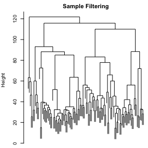

```r
sampleTree = hclust(dist(datExpr0), method = "average");

par(cex = 0.6);
par(mar = c(0,4,2,0))
plot(sampleTree, main = "Sample Filtering",
labels = FALSE)
```

```r
# final expression set ----------------------------------------------------
datExpr = datExpr0
```

## Exporting expression data for xCell signature analysis

For cell signature detection using xCell, the expression data can be written to a csv file. The file can be uploaded at: http://xcell.ucsf.edu

```r
Exps_for_xCell_analysis<-data.frame(t(datExpr), check.names = FALSE)

write.csv(Exps_for_xCell_analysis, file = "Exps_for_xCell_analysis.csv")
```

### The xCell results will be emailed to you.

Once you have the xCell data processed by http://xcell.ucsf.edu, you will receive an email linking to three text files. Download these files. For GmicR, the “xCell results” file is required for Step 3.

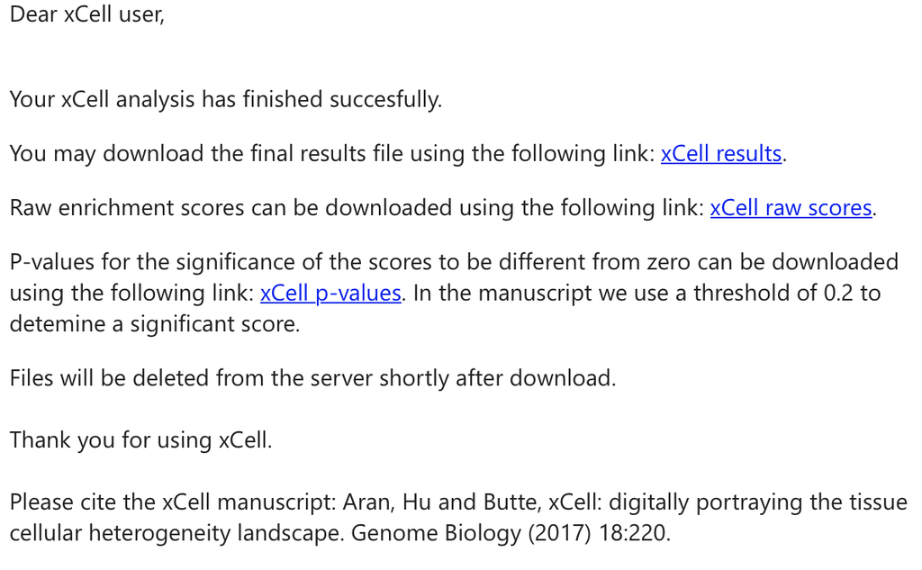

# Step 2 for GMIC building: gene module detection and annotation

For simplicity, we will carryout WGCNA using 1000 randomly selected genes from 50 randomly selected samples

```r
sample_ids<-sample(rownames(datExpr), 50) # 50 sampled rows
sample_genes<-sample(colnames(datExpr), 1000) # 1000 sampled columns
sample_dat<-datExpr[sample_ids,sample_genes] # data subset
```

## WGCNA module detection

Auto_WGCNA is a wrapper for WGCNA. Not all options are avaible. For more advanced features please use WGCNA.

```r
library(GmicR)

GMIC_Builder<-Auto_WGCNA(sample_dat,
  mergeCutHeight = 0.35, minModuleSize = 10,
  deepSplit = 4, networkType = "signed hybrid", TOMType = "unsigned",
  corFnc = "bicor",  sft_RsquaredCut = 0.85,
  reassignThreshold = 1e-06, maxBlockSize = 25000)
```

[output not shown]

Viewing input parameters

```r
GMIC_Builder$Input_Parameters
```

```
#> $networkType
#> [1] "signed hybrid"
#>
#> $TOMType
#> [1] "unsigned"
#>
#> $corFnc
#> [1] "bicor"
#>
#> $sft_RsquaredCut
#> [1] 0.85
#>
#> $softPower
#> [1] 5
#>
#> $minModuleSize
#> [1] 10
#>
#> $deepSplit
#> [1] 4
#>
#> $mergeCutHeight
#> [1] 0.35
#>
#> $reassignThreshold
#> [1] 1e-06
#>
#> $maxBlockSize
#> [1] 25000
```

Soft threshold plot

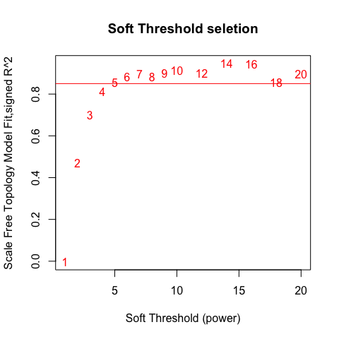

```r
GMIC_Builder$Output_plots$soft_threshold_plot
```

module clustering

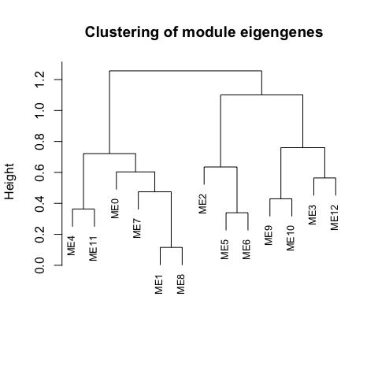

```r
GMIC_Builder$Output_plots$module_clustering
```

dendrogram

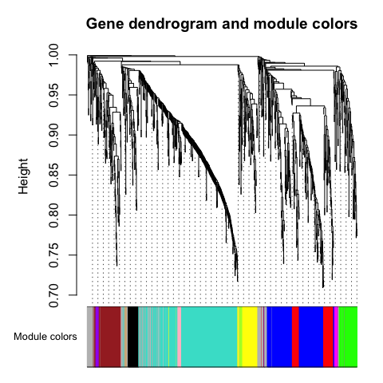

```r
GMIC_Builder$Output_plots$net_dendrogram
```

## Module annotation

WGCNA functions intramodularConnectivity and chooseOneHubInEachModule are used to build a dataframe with gene module information.

```r
# Module hubs and Gene influence
GMIC_Builder<-Query_Prep(GMIC_Builder,
  calculate_intramodularConnectivity= TRUE,
  Find_hubs = TRUE)

head(GMIC_Builder$Query)
```

[output not shown]

This function constructs a library for gene ontology enrichment, which will be used for module naming with the GO_Module_NameR function. Both functions were inspired by: https://www.bioconductor.org/packages/devel/bioc/vignettes/CVE/inst/doc/WGCNA_from_TCGA_RNAseq.html

```r
GMIC_Builder<-GSEAGO_Builder(GMIC_Builder,
  species = "Homo sapiens", ontology = "BP")
```

GO_Module_NameR will assign a name to each module based on ontology size. A smaller cut off size will generate a more specific term.

```r
GMIC_Builder<-GO_Module_NameR(GMIC_Builder, cutoff_size = 100)
```

This table provides a summary of detected modules. “Freq” indicates the total genes within each module

```r
head(GMIC_Builder$GO_table, n = 4)
```

```
#>              GO_module_name modules     hub Freq
#> ME0                module 0       0 SLC37A4  100
#> ME1           cell adhesion       1    SGCD  319
#> ME2 chromosome organization       2  ANP32B  187
#> ME3         cell activation       3 CYP27A1   88
```

A searchable dataframe is also generated

```r
head(GMIC_Builder$GO_Query, n = 4)
```

```
#>         modules ref_genes     hub Freq    kTotal   kWithin GO_module_name
#> SLC37A4       0   SLC37A4 SLC37A4  100 1.6525368 1.0000000       module 0
#> PEX10         0     PEX10 SLC37A4  100 1.6403205 0.8690595       module 0
#> GALNT12       0   GALNT12 SLC37A4  100 0.9325671 0.8025879       module 0
#> FGF3          0      FGF3 SLC37A4  100 2.2483526 0.7881512       module 0
```

# Step 3: Preparing module eigengenes and cell signatures for BN learning

## Specify the “xCell results” file directory

For this example, we are using cell signatures provided by the GmicR package, which were generated using the xCell web portal.

```r
file_dir<-system.file("extdata", "IRIS_xCell_sig.txt",
                      package = "GmicR", mustWork = TRUE)
```

## Discretization

This function merges module eigengenes with xCell signatures prior to discretization. Only xCell signatures are supported. Discretization is carried out with bnlearning using “hartemink” method. For detailed information discretization see: http://www.bnlearn.com/documentation/man/preprocessing.html

```r
GMIC_Builder_disc<-Data_Prep(GMIC_Builder,
  xCell_Signatures = file_dir,
ibreaks=10, Remove_ME0 = TRUE)
```

```
#> ImmuneScore, StromaScore, and MicroenvironmentScore removed
```

```r
head(GMIC_Builder_disc$disc_data[sample(seq(1,64),4)])
```

```
#>           Fibroblasts ME3 Neurons Monocytes
#> GSM565337           M   L       M         M
#> GSM565326           M   L       M         M
#> GSM565270           M   L       L         M
#> GSM565341           M   M       M         M
#> GSM565276           M   L       M         M
#> GSM565358           M   L       M         M
```

# Step 4: BN learning

## Bayesian network learing with bootstrapping.

Although the default score for this function is Bayesian Dirichlet equivalent score (bde), for this example we will use the Bayesian Dirichlet sparse score (bds). For sparse data, such as the data used in this example, the bds score is better suited: https://arxiv.org/abs/1605.03884.

```r
GMIC_net<-bn_tabu_gen(GMIC_Builder_disc,
  bootstraps_replicates = 50, score = "bds")
```

## Detecting arcs for inversly related nodes

For hypothesis generation, it may be helpful to distiguish positive relationships from negative. The InverseARCs function from GmicR identifies these relationships from probability distributions generated from mutilated network queries. A correlation matrix is generated and a threshold is applied to specify a slope cut off for inverse relationships. By default the threhold is set to -0.3.

```r
GMIC_Final<-InverseARCs(GMIC_net, threshold = -0.3)
```

## GmicR shiny app

Once complete, the GMIC network can be viewed using the Gmic_viz shiny app.

```r
GMIC_Final_dir<-system.file("extdata", "GMIC_Final.Rdata",
                          package = "GmicR", mustWork = TRUE)
load(GMIC_Final_dir)

if(interactive()){
Gmic_viz(GMIC_Final)
}
```

### GMIC_network_Query

You can view the entire network or just a subset of nodes. Inverse relationships can be highlighted based on color and/or edge pattern.

Not all nodes are represented:

- Module must have at least one connection
- xCell signature must have a relationship with a module

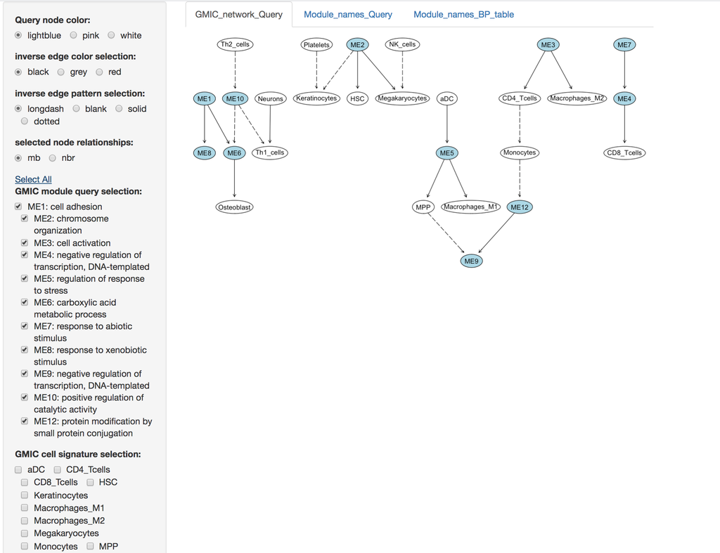

### Module_names_Query

You can search for your favorite gene or module of interest.

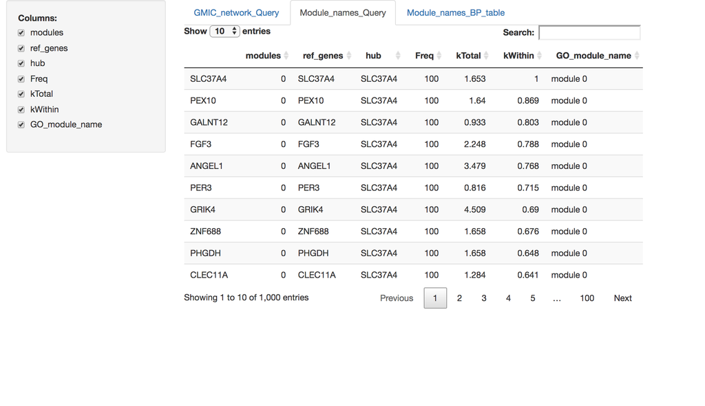

### Module_names_BP_table

Or view a module summary table

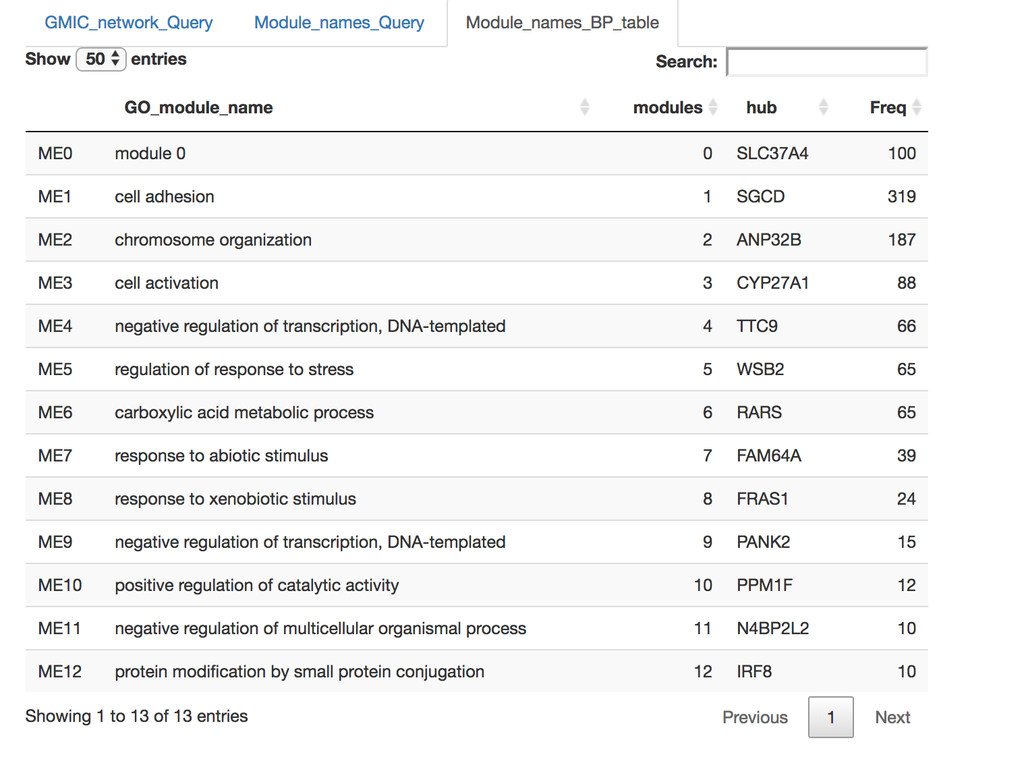